# Principal Components Analysis on Nutritional Information

## Introduction

PCA is fundamentally a dimensionality reduction algorithm, but it can also be useful as a tool for visualization, noise filtering and feature extraction.The data used for the project contains food items and a break down of their nutrients across 23 variables. After cleaning and performing a simple EDA, I will try to reduce the variables of the data set while retaining as much variance as possible.

1. Import Packages and Data
2. Data Verification
3. Exploratory Analysis
4. Principal Component Analysis
5. Data Tranformation
6. PCA After Transformation
7. Conclusion

## 1. Import Packages and Data

```python
import pandas as pd
import numpy as np
from sklearn.decomposition import PCA
from sklearn.preprocessing import StandardScaler
import matplotlib.pyplot as plt
import seaborn as sns
```

```python
df=pd.read_csv('nndb_flat.csv')

# Save the number of rows columns as a tuple
rows_and_cols = df.shape
print('There are {} rows and {} columns.\n'.format(
    rows_and_cols[0], rows_and_cols[1]))

# Generate an overview of the DataFrame
df_info = df.info()
print(df_info)

# Display the last five rows of the DataFrame
df.head()
```

```
There are 8618 rows and 45 columns.

<class 'pandas.core.frame.DataFrame'>
RangeIndex: 8618 entries, 0 to 8617
Data columns (total 45 columns):
 #   Column            Non-Null Count  Dtype
---  ------            --------------  -----
 0   ID                8618 non-null   int64
 1   FoodGroup         8618 non-null   object
 2   ShortDescrip      8618 non-null   object
 3   Descrip           8618 non-null   object
 4   CommonName        1063 non-null   object
 5   MfgName           1560 non-null   object
 6   ScientificName    732 non-null    object
 7   Energy_kcal       8618 non-null   float64
```

[output cut: 40 more lines]

|  | ID | FoodGroup | ShortDescrip | Descrip | CommonName | MfgName | ScientificName | Energy_kcal | Protein_g | Fat_g | ... | Folate_USRDA | Niacin_USRDA | Riboflavin_USRDA | Thiamin_USRDA | Calcium_USRDA | Copper_USRDA | Magnesium_USRDA | Phosphorus_USRDA | Selenium_USRDA | Zinc_USRDA |
| --- | --- | --- | --- | --- | --- | --- | --- | --- | --- | --- | --- | --- | --- | --- | --- | --- | --- | --- | --- | --- | --- |
| 0 | 1001 | Dairy and Egg Products | BUTTER,WITH SALT | Butter, salted | NaN | NaN | NaN | 717.0 | 0.85 | 81.11 | ... | 0.0075 | 0.002625 | 0.026154 | 0.004167 | 0.020000 | 0.000000 | 0.004762 | 0.034286 | 0.018182 | 0.008182 |
| 1 | 1002 | Dairy and Egg Products | BUTTER,WHIPPED,WITH SALT | Butter, whipped, with salt | NaN | NaN | NaN | 717.0 | 0.85 | 81.11 | ... | 0.0075 | 0.002625 | 0.026154 | 0.004167 | 0.020000 | 0.000018 | 0.004762 | 0.032857 | 0.018182 | 0.004545 |
| 2 | 1003 | Dairy and Egg Products | BUTTER OIL,ANHYDROUS | Butter oil, anhydrous | NaN | NaN | NaN | 876.0 | 0.28 | 99.48 | ... | 0.0000 | 0.000188 | 0.003846 | 0.000833 | 0.003333 | 0.000001 | 0.000000 | 0.004286 | 0.000000 | 0.000909 |
| 3 | 1004 | Dairy and Egg Products | CHEESE,BLUE | Cheese, blue | NaN | NaN | NaN | 353.0 | 21.40 | 28.74 | ... | 0.0900 | 0.063500 | 0.293846 | 0.024167 | 0.440000 | 0.000044 | 0.054762 | 0.552857 | 0.263636 | 0.241818 |
| 4 | 1005 | Dairy and Egg Products | CHEESE,BRICK | Cheese, brick | NaN | NaN | NaN | 371.0 | 23.24 | 29.68 | ... | 0.0500 | 0.007375 | 0.270000 | 0.011667 | 0.561667 | 0.000027 | 0.057143 | 0.644286 | 0.263636 | 0.236364 |

5 rows × 45 columns

## 2. Data Verification

```python
#null values
print(df.shape)
df.isna().sum()

#duplicate rows
df[df.duplicated()]

df['FoodGroup'].unique()
```

```
(8618, 45)
```

```
array(['Dairy and Egg Products', 'Spices and Herbs', 'Baby Foods',
       'Fats and Oils', 'Poultry Products', 'Soups, Sauces, and Gravies',
       'Sausages and Luncheon Meats', 'Breakfast Cereals', 'Snacks',
       'Fruits and Fruit Juices', 'Pork Products',
       'Vegetables and Vegetable Products', 'Nut and Seed Products',
       'Beef Products', 'Beverages', 'Finfish and Shellfish Products',
       'Legumes and Legume Products', 'Lamb, Veal, and Game Products',
       'Baked Products', 'Sweets', 'Cereal Grains and Pasta',
       'Fast Foods', 'Meals, Entrees, and Side Dishes',
       'American Indian/Alaska Native Foods', 'Restaurant Foods'],
      dtype=object)
```

```python
#drop columns with excessive missing values
df.drop(['CommonName','MfgName','ScientificName'],axis=1,inplace=True)
```

```python
#check for highly correlated features
corr=df.corr()
print(corr.where(corr> 0.90))
```

```
                   ID  Energy_kcal  Protein_g  Fat_g  Carb_g  Sugar_g  \
ID                1.0          NaN        NaN    NaN     NaN      NaN
Energy_kcal       NaN          1.0        NaN    NaN     NaN      NaN
Protein_g         NaN          NaN        1.0    NaN     NaN      NaN
Fat_g             NaN          NaN        NaN    1.0     NaN      NaN
Carb_g            NaN          NaN        NaN    NaN     1.0      NaN
Sugar_g           NaN          NaN        NaN    NaN     NaN      1.0
Fiber_g           NaN          NaN        NaN    NaN     NaN      NaN
VitA_mcg          NaN          NaN        NaN    NaN     NaN      NaN
VitB6_mg          NaN          NaN        NaN    NaN     NaN      NaN
VitB12_mcg        NaN          NaN        NaN    NaN     NaN      NaN
VitC_mg           NaN          NaN        NaN    NaN     NaN      NaN
VitE_mg           NaN          NaN        NaN    NaN     NaN      NaN
Folate_mcg        NaN          NaN        NaN    NaN     NaN      NaN
Niacin_mg         NaN          NaN        NaN    NaN     NaN      NaN
Riboflavin_mg     NaN          NaN        NaN    NaN     NaN      NaN
Thiamin_mg        NaN          NaN        NaN    NaN     NaN      NaN
Calcium_mg        NaN          NaN        NaN    NaN     NaN      NaN
Copper_mcg        NaN          NaN        NaN    NaN     NaN      NaN
Iron_mg           NaN          NaN        NaN    NaN     NaN      NaN
Magnesium_mg      NaN          NaN        NaN    NaN     NaN      NaN
Manganese_mg      NaN          NaN        NaN    NaN     NaN      NaN
Phosphorus_mg     NaN          NaN        NaN    NaN     NaN      NaN
Selenium_mcg      NaN          NaN        NaN    NaN     NaN      NaN
Zinc_mg           NaN          NaN        NaN    NaN     NaN      NaN
VitA_USRDA        NaN          NaN        NaN    NaN     NaN      NaN
VitB6_USRDA       NaN          NaN        NaN    NaN     NaN      NaN
VitB12_USRDA      NaN          NaN        NaN    NaN     NaN      NaN
VitC_USRDA        NaN          NaN        NaN    NaN     NaN      NaN
VitE_USRDA        NaN          NaN        NaN    NaN     NaN      NaN
Folate_USRDA      NaN          NaN        NaN    NaN     NaN      NaN
Niacin_USRDA      NaN          NaN        NaN    NaN     NaN      NaN
Riboflavin_USRDA  NaN          NaN        NaN    NaN     NaN      NaN
Thiamin_USRDA     NaN          NaN        NaN    NaN     NaN      NaN
Calcium_USRDA     NaN          NaN        NaN    NaN     NaN      NaN
Copper_USRDA      NaN          NaN        NaN    NaN     NaN      NaN
Magnesium_USRDA   NaN          NaN        NaN    NaN     NaN      NaN
Phosphorus_USRDA  NaN          NaN        NaN    NaN     NaN      NaN
Selenium_USRDA    NaN          NaN        NaN    NaN     NaN      NaN
Zinc_USRDA        NaN          NaN        NaN    NaN     NaN      NaN
```

[output cut: 151 more lines]

```
VitB12_USRDA                   NaN             NaN         NaN
VitC_USRDA                     NaN             NaN         NaN
VitE_USRDA                     NaN             NaN         NaN
Folate_USRDA                   NaN             NaN         NaN
Niacin_USRDA                   NaN             NaN         NaN
Riboflavin_USRDA               NaN             NaN         NaN
Thiamin_USRDA                  NaN             NaN         NaN
Calcium_USRDA                  NaN             NaN         NaN
Copper_USRDA                   NaN             NaN         NaN
Magnesium_USRDA                NaN             NaN         NaN
Phosphorus_USRDA               1.0             NaN         NaN
Selenium_USRDA                 NaN             1.0         NaN
Zinc_USRDA                     NaN             NaN         1.0

[39 rows x 39 columns]
```

```python
#drop redundant features
df.drop(df.columns[df.columns.str.contains('_USRDA')].values,
        inplace=True, axis=1)
```

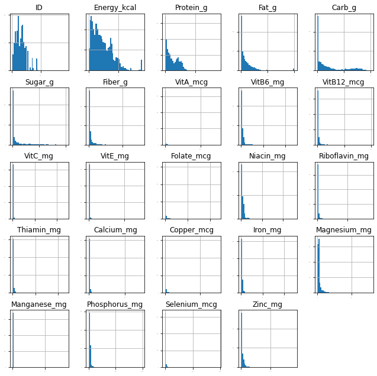

```python
ax = df.hist(bins=50, xlabelsize=-1, ylabelsize=-1, figsize=(11,11))
```

## 3. Preprocessing

```python
#separate continuous and categorical features
df.dtypes
cat_feat=df[['FoodGroup','ShortDescrip','Descrip']]
cont_feat= df.drop(['ID','FoodGroup','ShortDescrip','Descrip'], axis=1)
cf_col=cont_feat.columns
```

```python
# Scale data
# from sklearn.preprocessing import StandardScaler
cf = StandardScaler().fit_transform(cont_feat)

print("mean: ", np.round(cf.mean(), 2))
print("standard dev: ", np.round(cf.std(), 2))
```

```
mean:  0.0
standard dev:  1.0
```

## 4. Implement PCA

```python
# from sklearn.decomposition import PCA
fit = PCA()
pca = fit.fit_transform(cf)
```

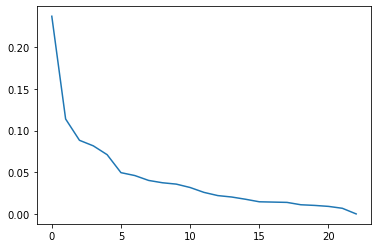

```python
plt.plot(fit.explained_variance_ratio_)
```

```python
print(fit.explained_variance_ratio_)
print(fit.explained_variance_ratio_[:7].sum())
```

```
[2.36925468e-01 1.13846015e-01 8.83433734e-02 8.17013669e-02
 7.11161480e-02 4.95813332e-02 4.61246638e-02 4.02719041e-02
 3.74790508e-02 3.58559322e-02 3.17927198e-02 2.59519549e-02
 2.21153503e-02 2.04113766e-02 1.77385355e-02 1.46927827e-02
 1.43290735e-02 1.39668837e-02 1.11392349e-02 1.03538827e-02
 9.18082227e-03 6.91711649e-03 1.65010749e-04]
0.6876383686066389
```

```python
# from sklearn.decomposition import PCA
fit = PCA(n_components=7)
pca = fit.fit_transform(cont_feat)
principalDF=pd.DataFrame(data=pca,columns=['pc1','pc2','pc3','pc4','pc5','pc6','pc7'])
```

```python
fit.components_
```

```
array([[ 6.49187840e-03,  3.88496728e-04,  5.16969456e-04,
         1.97144921e-04,  2.06415669e-04,  5.13899542e-05,
         9.99352212e-01,  8.70892463e-05,  3.22366597e-03,
         8.31205640e-03,  2.29027188e-04,  2.78156315e-02,
         9.73081392e-04,  1.91005662e-04,  3.84938749e-05,
         1.06495182e-02,  4.05254625e-04,  7.98993274e-04,
         2.11724515e-03,  3.03340123e-03,  1.63421643e-02,
         1.79019184e-03,  3.20137411e-04],
       [ 2.18077263e-01,  1.11743931e-02,  8.91456115e-03,
         2.77714931e-02,  5.87004809e-03,  4.67728927e-03,
        -2.62882914e-02,  5.63858259e-04,  1.04442687e-03,
         1.48974924e-02,  2.45222662e-03,  2.31474892e-01,
         5.76607562e-03,  5.64934899e-04,  5.53002036e-04,
         6.57347250e-01,  3.23966549e-04,  8.76104169e-03,
         1.03401897e-01,  1.64051777e-03,  6.73622963e-01,
         1.47516609e-02,  3.60997662e-03],
       [ 3.54000791e-01, -4.50344477e-03,  1.63815055e-02,
         5.90435902e-02,  1.72842742e-02,  4.78653976e-03,
        -2.11022646e-02,  1.11686511e-03,  1.06113506e-03,
         6.11820239e-03,  4.60454743e-03,  8.80076188e-01,
         1.13188488e-02,  1.04782770e-03,  1.31499654e-03,
        -2.09706525e-01,  6.69829646e-05,  1.09320242e-02,
         4.13446845e-02, -4.80993242e-05, -2.22689411e-01,
        -1.79508518e-03,  4.01600429e-03],
       [-8.80218140e-01, -8.09322958e-03, -7.57207355e-02,
        -4.35528295e-02, -1.48602469e-02, -6.04988086e-04,
        -6.82421256e-03,  4.86287565e-04,  1.47190266e-03,
         3.62878730e-02, -4.13957244e-03,  3.96793200e-01,
         2.74573517e-03,  4.11752178e-04,  2.91050523e-04,
         2.29686641e-01, -1.82558993e-04,  3.76500793e-03,
        -2.90370319e-02, -3.37986902e-04, -6.89201816e-02,
        -9.93185340e-03,  1.11324637e-03],
       [ 1.91536336e-01, -3.30773154e-02,  1.81046143e-02,
         4.24132000e-02,  2.63264046e-02,  2.80193056e-03,
         5.11836943e-03, -2.88374915e-04, -5.11178046e-03,
         4.76976486e-02,  2.71110462e-03, -9.10447909e-02,
        -5.81023341e-03, -1.09064670e-04, -2.66961430e-04,
         6.82859702e-01, -5.22535301e-04,  4.82958535e-03,
        -4.89895002e-02,  3.07695789e-05, -6.91001158e-01,
        -5.01481892e-02, -3.99117563e-03],
       [-3.70346454e-03, -4.62095520e-03, -1.32149199e-02,
         4.96182449e-02,  1.01259897e-02,  1.32215753e-02,
        -6.81096314e-03,  1.95049326e-03, -5.41011250e-03,
         9.45388629e-01,  4.85633650e-03, -3.76776154e-02,
         1.47815250e-02,  1.12180154e-03,  3.17960405e-04,
        -5.49925459e-02,  4.04966333e-04,  6.42215488e-03,
         3.13701214e-01,  1.86918867e-03, -3.55774790e-03,
        -7.58469478e-03,  1.04893936e-03],
       [ 5.97921619e-02, -1.07649385e-02,  3.34473494e-02,
        -7.38161691e-02,  1.02177511e-02, -3.91299672e-02,
        -3.94552862e-03, -1.64818022e-04,  4.60247646e-03,
         3.17348196e-01, -5.09406131e-03,  4.84667554e-02,
         8.73637943e-04,  3.73332839e-04, -5.03433274e-04,
         3.38077231e-03, -3.16998367e-03, -2.55208999e-02,
        -9.33997708e-01, -2.24520652e-02,  1.01035033e-01,
        -3.47930970e-02, -5.98928152e-03]])
```

```python
T = fit.components_.T
components=cf_col.tolist()
nut_df=pd.DataFrame(T,columns=('PC1','PC2','PC3','PC4','PC5','PC6','PC7'))
nut_df['variables']=components
nut_df
```

|  | PC1 | PC2 | PC3 | PC4 | PC5 | PC6 | PC7 | variables |
| --- | --- | --- | --- | --- | --- | --- | --- | --- |
| 0 | 0.006492 | 0.218077 | 0.354001 | -0.880218 | 0.191536 | -0.003703 | 0.059792 | Energy_kcal |
| 1 | 0.000388 | 0.011174 | -0.004503 | -0.008093 | -0.033077 | -0.004621 | -0.010765 | Protein_g |
| 2 | 0.000517 | 0.008915 | 0.016382 | -0.075721 | 0.018105 | -0.013215 | 0.033447 | Fat_g |
| 3 | 0.000197 | 0.027771 | 0.059044 | -0.043553 | 0.042413 | 0.049618 | -0.073816 | Carb_g |
| 4 | 0.000206 | 0.005870 | 0.017284 | -0.014860 | 0.026326 | 0.010126 | 0.010218 | Sugar_g |
| 5 | 0.000051 | 0.004677 | 0.004787 | -0.000605 | 0.002802 | 0.013222 | -0.039130 | Fiber_g |
| 6 | 0.999352 | -0.026288 | -0.021102 | -0.006824 | 0.005118 | -0.006811 | -0.003946 | VitA_mcg |
| 7 | 0.000087 | 0.000564 | 0.001117 | 0.000486 | -0.000288 | 0.001950 | -0.000165 | VitB6_mg |
| 8 | 0.003224 | 0.001044 | 0.001061 | 0.001472 | -0.005112 | -0.005410 | 0.004602 | VitB12_mcg |
| 9 | 0.008312 | 0.014897 | 0.006118 | 0.036288 | 0.047698 | 0.945389 | 0.317348 | VitC_mg |
| 10 | 0.000229 | 0.002452 | 0.004605 | -0.004140 | 0.002711 | 0.004856 | -0.005094 | VitE_mg |
| 11 | 0.027816 | 0.231475 | 0.880076 | 0.396793 | -0.091045 | -0.037678 | 0.048467 | Folate_mcg |
| 12 | 0.000973 | 0.005766 | 0.011319 | 0.002746 | -0.005810 | 0.014782 | 0.000874 | Niacin_mg |
| 13 | 0.000191 | 0.000565 | 0.001048 | 0.000412 | -0.000109 | 0.001122 | 0.000373 | Riboflavin_mg |
| 14 | 0.000038 | 0.000553 | 0.001315 | 0.000291 | -0.000267 | 0.000318 | -0.000503 | Thiamin_mg |
| 15 | 0.010650 | 0.657347 | -0.209707 | 0.229687 | 0.682860 | -0.054993 | 0.003381 | Calcium_mg |
| 16 | 0.000405 | 0.000324 | 0.000067 | -0.000183 | -0.000523 | 0.000405 | -0.003170 | Copper_mcg |
| 17 | 0.000799 | 0.008761 | 0.010932 | 0.003765 | 0.004830 | 0.006422 | -0.025521 | Iron_mg |
| 18 | 0.002117 | 0.103402 | 0.041345 | -0.029037 | -0.048990 | 0.313701 | -0.933998 | Magnesium_mg |
| 19 | 0.003033 | 0.001641 | -0.000048 | -0.000338 | 0.000031 | 0.001869 | -0.022452 | Manganese_mg |
| 20 | 0.016342 | 0.673623 | -0.222689 | -0.068920 | -0.691001 | -0.003558 | 0.101035 | Phosphorus_mg |
| 21 | 0.001790 | 0.014752 | -0.001795 | -0.009932 | -0.050148 | -0.007585 | -0.034793 | Selenium_mcg |
| 22 | 0.000320 | 0.003610 | 0.004016 | 0.001113 | -0.003991 | 0.001049 | -0.005989 | Zinc_mg |

#### Results

The first 7 eigenvectors account for 69% of the variance.

#### Interpreting Components

```python
#Component one
one = nut_df[['PC1','variables']]
one.sort_values('PC1',ascending=False).reset_index(drop=True)
```

|  | PC1 | variables |
| --- | --- | --- |
| 0 | 0.999352 | VitA_mcg |
| 1 | 0.027816 | Folate_mcg |
| 2 | 0.016342 | Phosphorus_mg |
| 3 | 0.010650 | Calcium_mg |
| 4 | 0.008312 | VitC_mg |
| 5 | 0.006492 | Energy_kcal |
| 6 | 0.003224 | VitB12_mcg |
| 7 | 0.003033 | Manganese_mg |
| 8 | 0.002117 | Magnesium_mg |
| 9 | 0.001790 | Selenium_mcg |
| 10 | 0.000973 | Niacin_mg |
| 11 | 0.000799 | Iron_mg |
| 12 | 0.000517 | Fat_g |
| 13 | 0.000405 | Copper_mcg |
| 14 | 0.000388 | Protein_g |
| 15 | 0.000320 | Zinc_mg |
| 16 | 0.000229 | VitE_mg |
| 17 | 0.000206 | Sugar_g |
| 18 | 0.000197 | Carb_g |
| 19 | 0.000191 | Riboflavin_mg |
| 20 | 0.000087 | VitB6_mg |
| 21 | 0.000051 | Fiber_g |
| 22 | 0.000038 | Thiamin_mg |

## 4. Transformation

Transformations may improve distribution and produce better correlation for the pca. Among the options for right skewed data are boxcox, cubed root, square root and log tranformations.

```python
#boxcox tranformation
def boxcox(x):
    return (((x**0.242)-1)/2)

cf_t=boxcox(cont_feat1)
cf_t
```

|  | Energy_kcal | Protein_g | Fat_g | Carb_g | Sugar_g | Fiber_g | VitA_mcg | VitB6_mg | VitB12_mcg | VitC_mg | ... | Riboflavin_mg | Thiamin_mg | Calcium_mg | Copper_mcg | Iron_mg | Magnesium_mg | Manganese_mg | Phosphorus_mg | Selenium_mcg | Zinc_mg |
| --- | --- | --- | --- | --- | --- | --- | --- | --- | --- | --- | --- | --- | --- | --- | --- | --- | --- | --- | --- | --- | --- |
| 0 | 1.954741 | -0.019283 | 0.948658 | -0.246906 | -0.246906 | -0.5 | 1.926909 | -0.377416 | -0.174359 | -0.5 | ... | -0.279409 | -0.361286 | 0.578900 | -0.500000 | -0.305992 | 0.091316 | -0.500000 | 0.578900 | 0.000000 | -0.220812 |
| 1 | 1.954741 | -0.019283 | 0.948658 | -0.246906 | -0.246906 | -0.5 | 1.926909 | -0.377416 | -0.194828 | -0.5 | ... | -0.279409 | -0.361286 | 0.578900 | -0.316191 | -0.179102 | 0.091316 | -0.368578 | 0.567845 | 0.000000 | -0.257830 |
| 2 | 2.076653 | -0.132564 | 1.022026 | -0.500000 | -0.500000 | -0.5 | 2.050619 | -0.406034 | -0.335952 | -0.5 | ... | -0.361286 | -0.406034 | 0.199308 | -0.406034 | -0.500000 | -0.500000 | -0.500000 | 0.152279 | -0.500000 | -0.335952 |
| 3 | 1.567909 | 0.549374 | 0.627000 | 0.114215 | -0.077214 | -0.5 | 1.297889 | -0.176230 | 0.024649 | -0.5 | ... | -0.103878 | -0.287739 | 1.779541 | -0.270560 | -0.123401 | 0.567845 | -0.340082 | 1.614443 | 0.455039 | 0.133565 |
| 4 | 1.592948 | 0.570531 | 0.635812 | 0.140924 | -0.075183 | -0.5 | 1.475116 | -0.241955 | 0.028761 | -0.5 | ... | -0.111908 | -0.322036 | 1.918275 | -0.297241 | -0.092367 | 0.578900 | -0.328552 | 1.694223 | 0.455039 | 0.130077 |
| ... | ... | ... | ... | ... | ... | ... | ... | ... | ... | ... | ... | ... | ... | ... | ... | ... | ... | ... | ... | ... | ... |
| 8613 | 1.496046 | 0.513038 | 0.590664 | -0.500000 | -0.500000 | -0.5 | 0.769456 | -0.097038 | 0.412288 | -0.5 | ... | -0.165475 | -0.305992 | 0.878160 | -0.213602 | 0.042417 | 0.846736 | -0.500000 | 1.409588 | 0.914062 | 0.011667 |
| 8614 | 1.062925 | 0.539009 | -0.020658 | 0.252322 | -0.500000 | -0.5 | 0.091316 | -0.205639 | 0.101756 | -0.5 | ... | -0.297241 | -0.328552 | 0.372911 | -0.280997 | -0.061752 | 0.698050 | -0.287739 | 1.664149 | 0.552915 | 0.055943 |
| 8615 | 1.436288 | -0.500000 | -0.500000 | 0.912848 | 0.913129 | -0.5 | -0.500000 | -0.500000 | -0.500000 | -0.5 | ... | -0.246906 | -0.194828 | 0.430131 | -0.305992 | 0.181703 | 0.372911 | -0.500000 | 0.327023 | -0.041348 | -0.165475 |
| 8616 | 0.985582 | 0.479539 | 0.042417 | 0.091316 | -0.500000 | -0.5 | 0.638763 | -0.194828 | -0.077214 | -0.5 | ... | -0.200683 | -0.335952 | 0.372911 | -0.099439 | 0.177071 | 1.402267 | -0.500000 | 1.441492 | 0.614052 | 0.000000 |
| 8617 | 0.981571 | 0.529824 | -0.077214 | -0.500000 | -0.500000 | -0.5 | 0.638763 | -0.200683 | 0.000000 | -0.5 | ... | -0.184075 | -0.200683 | 1.086227 | -0.142504 | 0.042417 | 0.532332 | -0.500000 | 1.256896 | 0.489680 | 0.000000 |

8618 rows × 23 columns

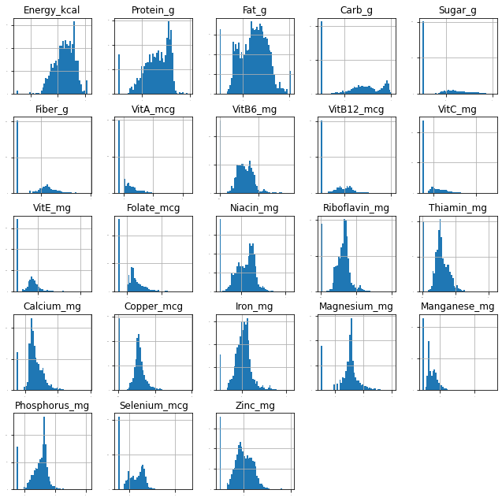

```python
# Distribution of variable after tranformation
ax = cf_t.hist(bins=50, xlabelsize=-1, ylabelsize=-1, figsize=(11,11))
```

```python
#scale data
# from sklearn.preprocessing import StandardScaler
cft_scaled = StandardScaler().fit_transform(cf_t)

print("mean: ", np.round(cft_scaled.mean(), 2))
print("standard dev: ", np.round(cont_feat.std(), 2))
```

```
mean:  0.0
standard dev:  Energy_kcal      169.39
Protein_g         10.55
Fat_g             15.87
Carb_g            27.24
Sugar_g           13.60
Fiber_g            4.31
VitA_mcg         779.36
VitB6_mg           0.48
VitB12_mcg         4.32
VitC_mg           57.58
VitE_mg            3.85
Folate_mcg       186.56
Niacin_mg          4.83
Riboflavin_mg      0.45
Thiamin_mg         0.52
Calcium_mg       201.36
Copper_mcg         0.55
Iron_mg            5.73
Magnesium_mg      56.07
Manganese_mg       6.38
Phosphorus_mg    203.09
Selenium_mcg      28.29
Zinc_mg            3.36
dtype: float64
```

## 6. PCA with Tranformation

```python
# from sklearn.decomposition import PCA
fit = PCA()
pca = fit.fit_transform(cft_scaled)
```

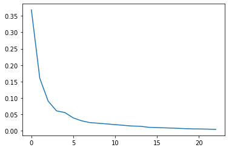

```python
plt.plot(fit.explained_variance_ratio_)
```

```python
print(fit.explained_variance_ratio_)
print(fit.explained_variance_ratio_[:6].sum())
```

```
[0.36860099 0.16022227 0.09040519 0.06054968 0.05547001 0.03909204
 0.03025885 0.02474688 0.02286983 0.0207521  0.01866831 0.01648488
 0.01441782 0.01362777 0.01044389 0.00968577 0.0086944  0.00795703
 0.00676082 0.00583752 0.00540865 0.00490082 0.00414448]
0.7743401764901862
```

```python
#from sklearn.decomposition import PCA
fit = PCA(n_components=6)
pca = fit.fit_transform(cont_feat)
principalDF=pd.DataFrame(data=pca,columns=['pc1','pc2','pc3','pc4','pc5','pc6'])
```

```python
T_2 = fit.components_.T
components=cf_col.tolist()
nut_df2=pd.DataFrame(PCloadings,columns=('PC1','PC2','PC3','PC4','PC5','PC6'))
nut_df2['variables']=components
nut_df2
```

[output not shown]

#### Results

The first 6 eigenvectors account for 77% of the variance.

#### Interpreting Components

```python
#component one
one = nut_df2[['PC1','variables']]
one.sort_values('PC1',ascending=False).reset_index(drop=True)

#high in Vitamin A, Folate, Phosphorus
#low in Thiamin, Fibre, Vitamin B6
```

|  | PC1 | variables |
| --- | --- | --- |
| 0 | 0.999352 | VitA_mcg |
| 1 | 0.027816 | Folate_mcg |
| 2 | 0.016342 | Phosphorus_mg |
| 3 | 0.010650 | Calcium_mg |
| 4 | 0.008312 | VitC_mg |
| 5 | 0.006492 | Energy_kcal |
| 6 | 0.003224 | VitB12_mcg |
| 7 | 0.003033 | Manganese_mg |
| 8 | 0.002117 | Magnesium_mg |
| 9 | 0.001790 | Selenium_mcg |
| 10 | 0.000973 | Niacin_mg |
| 11 | 0.000799 | Iron_mg |
| 12 | 0.000517 | Fat_g |
| 13 | 0.000405 | Copper_mcg |
| 14 | 0.000388 | Protein_g |
| 15 | 0.000320 | Zinc_mg |
| 16 | 0.000229 | VitE_mg |
| 17 | 0.000206 | Sugar_g |
| 18 | 0.000197 | Carb_g |
| 19 | 0.000191 | Riboflavin_mg |
| 20 | 0.000087 | VitB6_mg |
| 21 | 0.000051 | Fiber_g |
| 22 | 0.000038 | Thiamin_mg |

## Conclusion

The PCA algorithm preprocessed by scaling and transforming yielded the best result. The Principal Component Analysis using a boxcox tranformation resulted in 23 variables reduced to six components while still accounting for 77% of the overall variance. Components can be interpreted, to find the influence of each variable however it requires deep subject expertise (nutritionist) to enhance the analysis. PCA algorithms are often used prior to a K-Means cluster analysis.